# Linear Regression - Notebook

This is an [R Markdown](http://rmarkdown.rstudio.com) Notebook for exploring linear regression. When you execute code within the notebook, the results appear beneath the code.

We would at times want to measure how two parameters of interest are connnected, lets explore a dataset of ours to explore that. We will use the glasshouse data in the shading experiment.

```r
greenhouse_data <- read.csv('data/Greenhouse_data_TH/het data-Table 1.csv',header = TRUE,as.is = TRUE,na.strings = "n/a")
str(greenhouse_data)
```

```
'data.frame':   863 obs. of  19 variables:
 $ plant.h          : int  1 2 3 5 6 7 8 10 11 12 ...
 $ block            : int  1 1 1 1 1 1 1 1 1 1 ...
 $ treatment        : chr  "c" "c" "c" "c" ...
 $ position         : int  1 2 3 5 6 1 2 4 5 6 ...
 $ source.pop       : chr  "NUH" "SCH" "SSH" "SHH" ...
 $ source.pop.number: int  9 11 15 12 11 13 13 10 14 7 ...
 $ source.fam       : chr  "NUH11" "SCH15" "SSH7" "SHH5" ...
 $ field.greenhouse : chr  "G" "G" "G" "G" ...
 $ first.flower     : int  113 105 105 92 105 105 105 99 99 92 ...
 $ rosette.diameter : num  24 28.7 21 22 21.3 ...
 $ height           : num  5 10 6 8 5 6 6 7 5 4 ...
 $ leaf.length      : num  12.24 15.21 7.13 13.8 11.51 ...
 $ SLA              : num  35.6 26.1 38.9 36.7 25.8 ...
 $ branch.length    : num  NA NA NA NA NA 70 NA NA NA NA ...
 $ internode.number : chr  NA NA NA NA ...
 $ internode.length : num  NA NA NA NA NA ...
 $ biomass          : num  2.34 NA NA NA NA 2.66 NA NA NA NA ...
 $ seeds.per.fruit  : num  5 4.8 5 5 4.8 5 5 5 4.8 5 ...
 $ fruits           : chr  "71" "99" "121" "102" ...
```

Do the summary statistics to get a sense of the data

```r
summary(greenhouse_data)
```

```
    plant.h          block        treatment            position      source.pop        source.pop.number
 Min.   :  1.0   Min.   : 1.00   Length:863         Min.   :1.000   Length:863         Min.   : 1.000
 1st Qu.:231.5   1st Qu.: 7.00   Class :character   1st Qu.:2.000   Class :character   1st Qu.: 5.000
 Median :451.0   Median :13.00   Mode  :character   Median :4.000   Mode  :character   Median : 9.000
 Mean   :451.5   Mean   :13.03                      Mean   :3.513                      Mean   : 8.803
 3rd Qu.:672.5   3rd Qu.:19.00                      3rd Qu.:5.000                      3rd Qu.:13.000
 Max.   :900.0   Max.   :25.00                      Max.   :6.000                      Max.   :16.000

  source.fam        field.greenhouse    first.flower   rosette.diameter     height       leaf.length
 Length:863         Length:863         Min.   : 92.0   Min.   : 7.67    Min.   : 3.00   Min.   : 5.322
 Class :character   Class :character   1st Qu.: 99.0   1st Qu.:22.00    1st Qu.: 8.00   1st Qu.:12.178
 Mode  :character   Mode  :character   Median :105.0   Median :26.00    Median :11.00   Median :14.989
                                       Mean   :107.6   Mean   :26.02    Mean   :11.16   Mean   :15.055
                                       3rd Qu.:113.0   3rd Qu.:29.67    3rd Qu.:14.00   3rd Qu.:17.654
                                       Max.   :132.0   Max.   :44.67    Max.   :26.00   Max.   :27.345
                                       NA's   :2       NA's   :2        NA's   :2       NA's   :20
      SLA        branch.length    internode.number   internode.length    biomass      seeds.per.fruit
 Min.   :14.95   Min.   : 39.00   Length:863         Min.   : 3.900   Min.   :1.160   Min.   :2.600
 1st Qu.:30.42   1st Qu.: 65.00   Class :character   1st Qu.: 6.900   1st Qu.:2.370   1st Qu.:4.600
 Median :35.46   Median : 72.00   Mode  :character   Median : 7.556   Median :2.660   Median :5.000
 Mean   :36.16   Mean   : 72.13                      Mean   : 7.667   Mean   :2.803   Mean   :4.797
 3rd Qu.:40.19   3rd Qu.: 79.75                      3rd Qu.: 8.444   3rd Qu.:3.130   3rd Qu.:5.000
 Max.   :75.66   Max.   :105.00                      Max.   :11.333   Max.   :5.510   Max.   :5.000
 NA's   :20      NA's   :189                         NA's   :245      NA's   :134     NA's   :117
    fruits
 Length:863
 Class :character
 Mode  :character
```

We could explore the relationship between leaf length and height of the plant, and see if there is any correlation.

Best way to visualize it first by doing a simple plot, think of normal cartersian coordinates and we do point plotting(x,y). Recollect what x & y would mean with regards to dependent and independent variables.

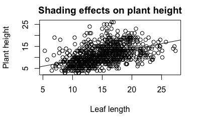

```r
plot(data=na.omit(greenhouse_data), x=greenhouse_data$leaf.length, y=greenhouse_data$height,
     main="Shading effects on plant height", xlab="Leaf length", ylab="Plant height")
#TODO omit the n/A rows
abline(lm(greenhouse_data$height ~ greenhouse_data$leaf.length))
```

Linear regression gives a way to measure correlation, and most prevalent way is to give it as a coorelation coefficient. R gives us a way to extract that for two variables.

```r
 # Looks like very ideal linear positive relationship, but we ought to be not subjective.
lm(data=greenhouse_data, greenhouse_data$height~greenhouse_data$leaf.length)
```

```
Call:
lm(formula = greenhouse_data$height ~ greenhouse_data$leaf.length,
    data = greenhouse_data)

Coefficients:
                (Intercept)  greenhouse_data$leaf.length
                     3.4043                       0.5142
```

Lets inspect it more, and need to invoke summary() function to get correlation coefficient.

```r
 # Looks like very ideal linear positive relationship, but we ought to be not subjective.
summary(lm(data=greenhouse_data, greenhouse_data$height~greenhouse_data$leaf.length))
```

```
Call:
lm(formula = greenhouse_data$height ~ greenhouse_data$leaf.length,
    data = greenhouse_data)

Residuals:
    Min      1Q  Median      3Q     Max
-8.1764 -2.7542 -0.4976  2.1939 14.0555

Coefficients:
                            Estimate Std. Error t value Pr(>|t|)
(Intercept)                  3.40433    0.53280   6.389 2.76e-10 ***
greenhouse_data$leaf.length  0.51416    0.03429  14.994  < 2e-16 ***
---
Signif. codes:  0 ‘***’ 0.001 ‘**’ 0.01 ‘*’ 0.05 ‘.’ 0.1 ‘ ’ 1

Residual standard error: 3.8 on 840 degrees of freedom
  (21 observations deleted due to missingness)
Multiple R-squared:  0.2111,    Adjusted R-squared:  0.2102
F-statistic: 224.8 on 1 and 840 DF,  p-value: < 2.2e-16
```

```r
lmph<- lm(data=greenhouse_data, greenhouse_data$height~greenhouse_data$leaf.length)
```

Ideally, coorelation coefficient is squared, so what you see R give out is R-squared, which is basically square of correlation coeffcient.

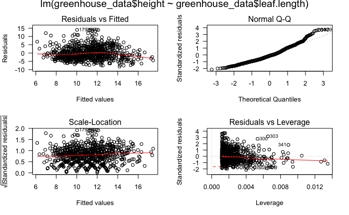

```r
opar <- par(mfrow = c(2,2), oma = c(0, 0, 1.1, 0))
plot(lmph, las = 1)      # Residuals, Fitted, ...
par(opar)
```